# Causal Inference and Randomized Experiments

Lecture 6

## Part 2

In part 2 of EC3301 we are going to tackle a range of topics that are both,

1. applied throughout modern empirical research;
2. central to the way economists think about causal inference.

**Warning**

I may make *small* changes to the syllabus over the next few weeks as I develope the material.

## Today

Today’s lecture is inspired by the humble sandwich.

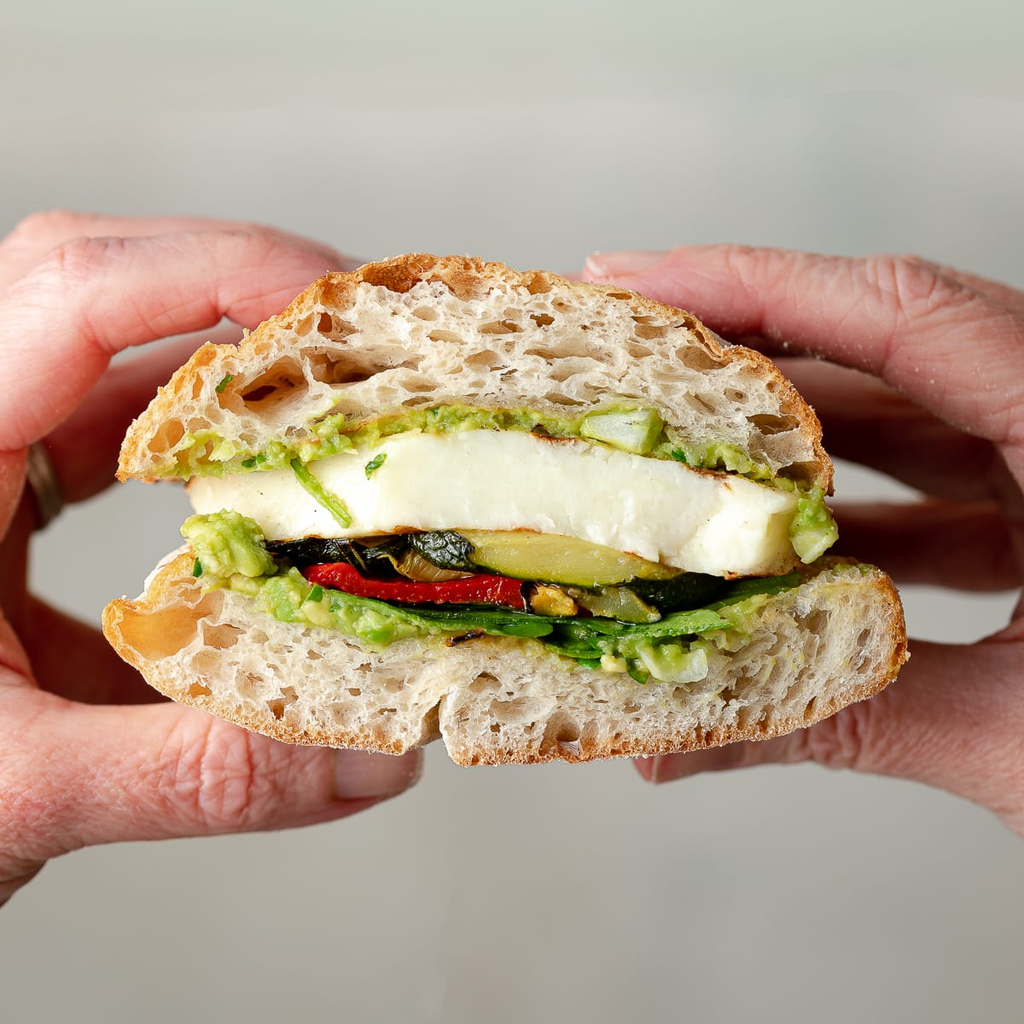

The quintessential British meal.

# Example: Dizon-Ross (2019)

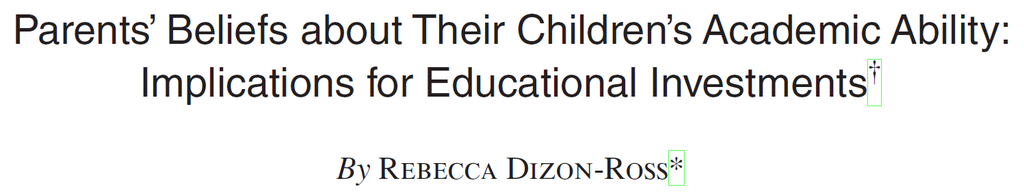

**In a nutshell**

Rural Malawi in 2012. School is free, but parents still spend money on their children’s education. They have to decide on how much to invest based on what they know their children’s academic potential. In reality, they have very poor (inaccurate) knowledge of their children’s academic performance.

**What would happen if you provided parents with more accessible information?** Would they invest more? Differently?

## Research Design

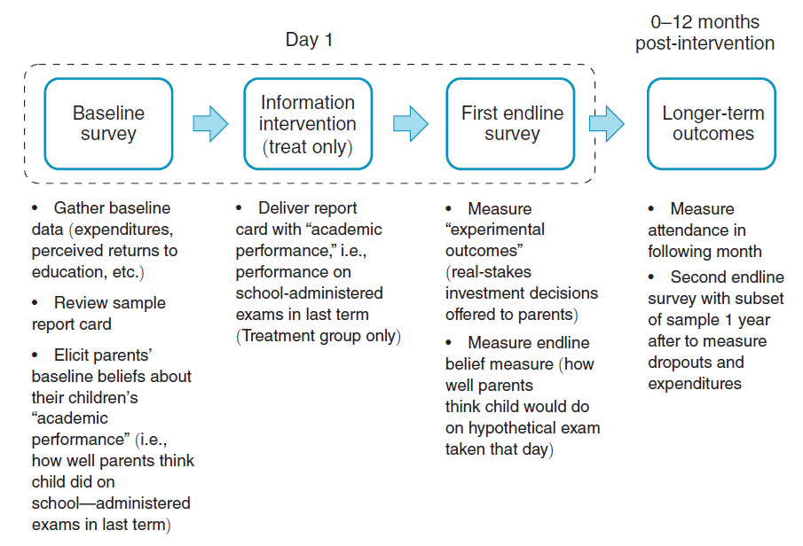

Figure 2 (p. 2741)

## Balance

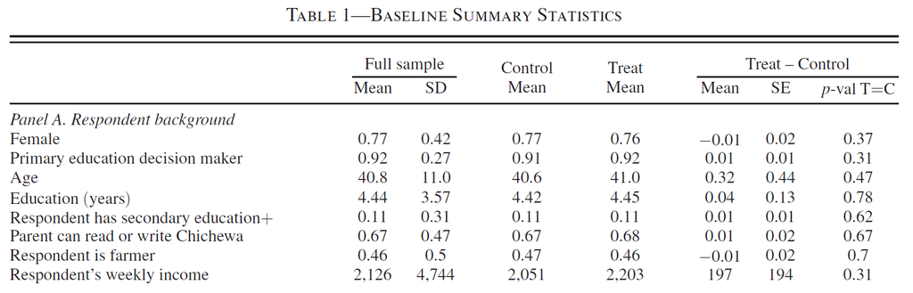

Table 1 (p. 2743)

## Simple difference between means

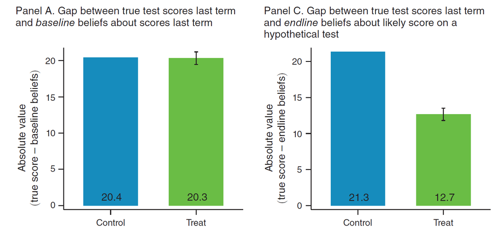

Figure 3 (p. 2745)

## Heterogeneity

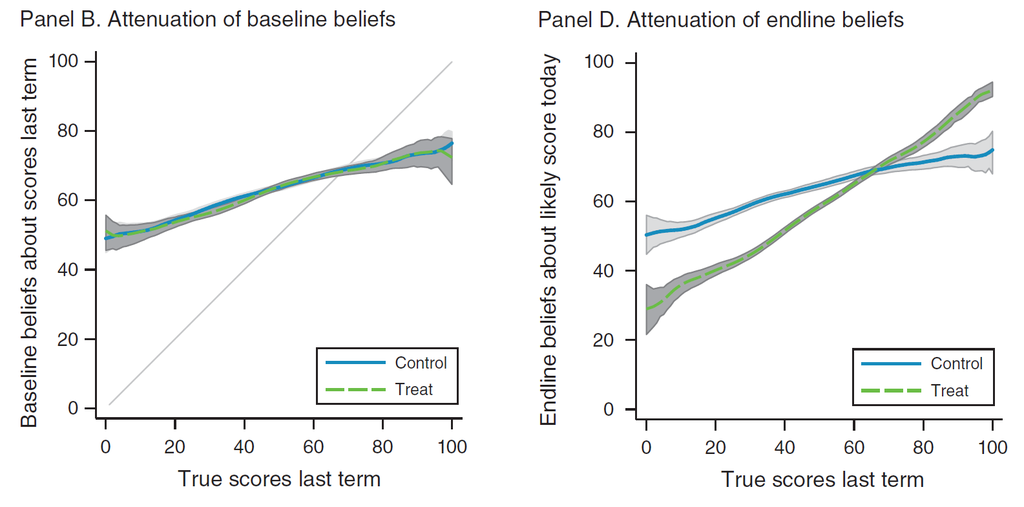

Figure 3 (p. 2745)

## Regression

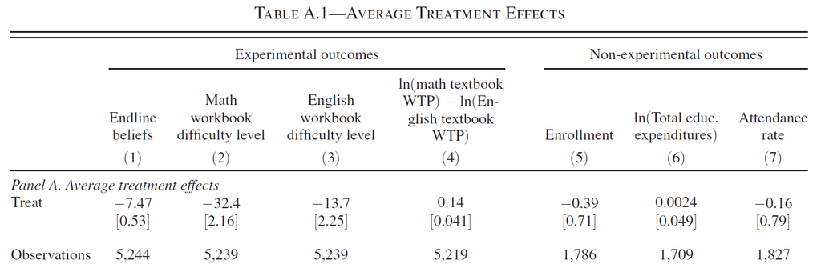

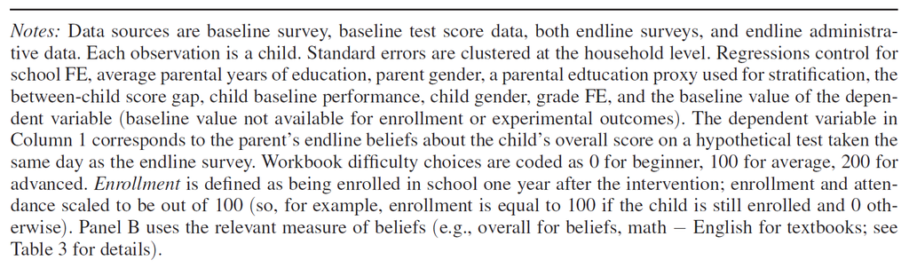

# Potential Outcomes Framework

## Neyman-Rubin Causal Model

The Potential Outcomes Framework is a key component of the Neyman-Rubin Causal Model<sup>1</sup>

- We won’t cover all aspects of this model.
- I will reference texts in green boxes that you can visit to read further
[^1]: Also referred to as the Rubin Causal Model (originally by Holland 1986). The framework is attributed to both Jerzy Neyman and Donald Rubin; as well as Paul Holland (Heckman and Pinto 2022).

## Component 1

The Neyman-Rubin model has three important components (Imbens and Rubin 2015)

> **Potential Outcomes**: The outcomes corresponding to different levels of treatment or manipulation: “no causation without manipulation” (Rubin 1975, 238)
- Potential outcomes are *a priori* observable, but *a posteriori* only one outcome is observable.
- A variable can only be a “cause” if it is possible, at least in principle, to conceive of a hypothetical or physical intervention (“treatment”) that manipulates it. We tend not to discuss the causal effect of demographic characteristics.<sup>1</sup>
[^2]: The caveat here might be hypothetical resume studies; e.g. Bertrand and Mullainathan (2004) and Oreopoulos (2011).

## Components 2

> **Multiple units**: Given the limit on observation, one must observe multiple units to infer a causal effect.
- Need to make a key stability assumption: Stable Unit Treatment Value Assumption (SUTVA).

## Component 3

> **Assignment mechanism**: The function that determines the manipulation of units.

Assignment may be:

- **probabilistic**; e.g. randomized experiment
- **deterministic**; e.g. thresholds/cutoffs
- **conditional**; depend partly depend on observable characteristics ($\mathbf{x}_i$).
- **controlled** (by the researcher); e.g. randomized control trial
- **exogenous** (to the treatment unit); e.g. public policy or natural experiments<sup>1</sup>
- **known** (by the researcher); e.g. controlled or natural experiments
- **unknown**; e.g. observational study,
[^3]: Often referred to as quasi-experiment.

## Example

Consider the example of Dizon-Ross (2019): there are two possible *states of the world*:

**Treated**:

- receive information

Researcher observes:

$$y(\text{info})$$

**Untreated**: (*control*)

- no information (status-quo)

Researcher observes:
$$y(\text{status-quo})$$

We call these **potential outcomes**.

## Possible outcomes

For a discrete outcome like enrollment there are 4 possible outcomes:

1. Enroll only with information

   $$y(\text{info})=\textcolor{red}{\text{enroll}} \qquad \text{and}\qquad y(\text{status-quo})=\textcolor{blue}{\text{don't enroll}}$$
2. Enroll, regardless

   $$y(\text{info})=\textcolor{red}{\text{enroll}} \qquad \text{and}\qquad y(\text{status-quo})=\textcolor{red}{\text{enroll}}$$
3. Don’t enroll, regardless

   $$y(\text{info})=\textcolor{blue}{\text{don't enroll}} \qquad \text{and}\qquad y(\text{status-quo})=\textcolor{blue}{\text{don't enroll}}$$
4. Enroll only without information

   $$y(\text{info})=\textcolor{blue}{\text{don't enroll}} \qquad \text{and}\qquad y(\text{status-quo})=\textcolor{red}{\text{enroll}}$$

## Causal effect

According to the Neyman-Rubin Causal Model, in:

- scenarios (1) **and** (4) there has been a **causal effect**
- scenarios (2) **and** (3) there has been NO *causal effect*.

**Important**

Notice two things (Imbens and Rubin 2015, 6),

1. “First, the definition of the causal effect depends on the potential outcomes, but it does not depend on which outcome is actually observed.”

2 “Second, the causal effect is the comparison of potential outcomes, for the same unit, at the same moment in time post-treatment. In particular, the causal effect is not defined in terms of comparisons of outcomes at different times.”

## Notation

Let $w_i \in \{0,1\}$ be an indicator of an individuals *discrete* treatment status.<sup>1</sup>:

- $y_i\small{(1)}$ be the potential outcome when treated
- $y_i\small{(0)}$ be the potential outcome when not treated<sup>2</sup>
[^4]: This notation of $w_i$ as an indicator of an unit’s treatment status is common in the literature on experiments and is used in one of the seminal books on the topic: Imbens and Rubin (2015)’s *Causal Inference in Statistics, Social, and Biomedical Sciences*. You will see it in Wooldridge (2025, sec. 7.6).
[^5]: You will see other notations in the literature. For example, the use of superscripts $\{y_i^1,y_i^0\}$ or subscripts $\{y_{i1},y_{i0}\}$.

## Observed outcome

*A priori*, both potential outcomes could be realised, but **in the data you observe only one**:

$$y_i = \begin{cases}y_i\small{(1)}\quad \text{if}\; w_i=1 \\
y_i\small{(0)}\quad \text{if}\; w_i=0
\end{cases}$$

> “fundamental problem of causal inference” (Holland 1986, 947)

Which we can write this as a linear function:

$$y_i = y_i\small{(0)} + w_i\big(y_i\small{(1)}-y_i\small{(0)}\big)$$

## ITE

The individual (unit) treatment effect (ITE) is defined as,

$$\tau_i = y_i\small{(1)}-y_i\small{(0)}$$

However, *you cannot observe (identify) or estimate the ITE*

**WHY?**

- it would require you to observe **both** potential outcomes of the same unit *in the same period*
- referred to as the “missing data problem” (Imbens and Rubin 2015, 34)

**Notice!**

- the individual level treatment effect varies at the individual level: $\tau_i$

## Visualization

*A priori*, both potential outcomes are observable

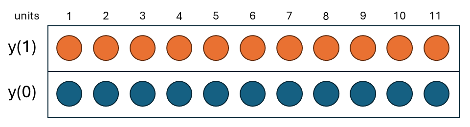

Then, treatment is assigned

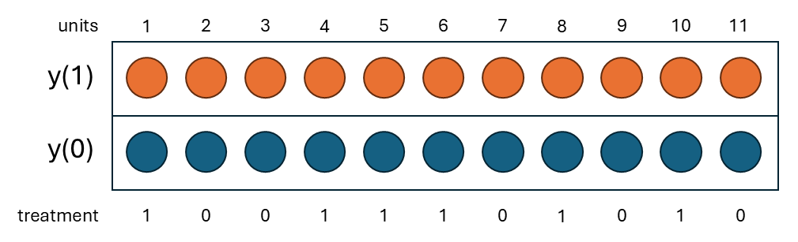

Treatment determines which PO you observe

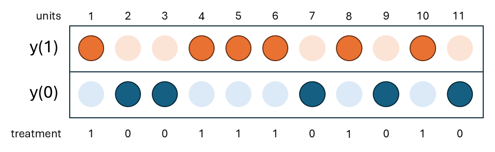

There is an observed outcome and (theoretically) a missing one

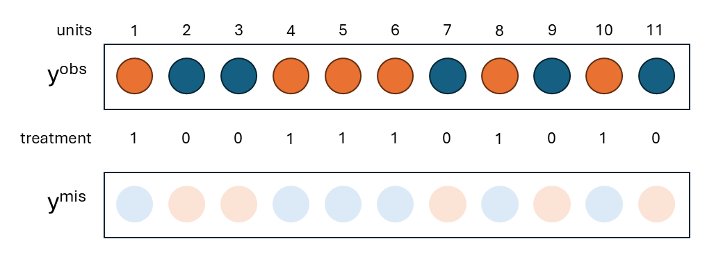

## Average TEs

In place of the ITE, we focus on identifying and estimating average TEs

- Average Treatment Effect (ATE)

  $$\tau_{ate} = E[\tau_i] = E\big[y_i\small{(1)}-y_i\small{(0)}\big]$$
- Average Treatment Effect of the Treated (ATT)

  $$\tau_{att} = E[\tau_i|w_i = 1] = E\big[y_i\small{(1)}-y_i\small{(0)}|w_i=1\big]$$
- Average Treatment Effect of the Untreated (ATU)

  $$\tau_{atu} = E[\tau_i|w_i = 0] = E\big[y_i\small{(1)}-y_i\small{(0)}|w_i=0\big]$$

  These are called **causal estimands**

## ATE vs ATT

We prefer the **ATE** if,

- we want to learn about the effect on the entire population;
- i.e., mandatory exposure.
- or lottery

We prefer the **ATT** if,

- the population includes individuals that will not take up the treatment/policy;
- e.g., a policy that targets single mothers;
- or program is voluntary,

The ATT is “informative about the effect of entirely eliminating the current program” (Imbens and Wooldridge 2009, 14–15).

# Assignment

## Two groups

Suppose you treat one group of individuals, while observing another untreated. Then *in expectation*, you can learn about

$$E[y_i|w_i = 1] - E[y_i|w_i = 0]$$

Substituting in $y_i = y_i\small{(0)} + w_i\big(y_i\small{(1)}-y_i\small{(0)}\big)$

$$E[y_i\small{(1)}|w_i = 1] - E[y_i\small{(0)}|w_i = 0]$$

Is this equal to either the ATE, ATT, or ATU? **NO!**
$$E[y_i\small{(1)}|\textcolor{red}{w_i = 1}] - E[y_i\small{(0)}|\textcolor{blue}{w_i = 0}]$$

**Why?**

- The conditions are not the same!

## Decomposition

Let us add and subtract:

$$\textcolor{red}{E[y_i\small{(0)}|w_i = 1]}$$

the **unobserved counterfactual** for the treated group.

$$E[y_i\small{(1)}|w_i = 1] - \textcolor{red}{E[y_i\small{(0)}|w_i = 1]} + \textcolor{red}{E[y_i\small{(0)}|w_i = 1]}- E[y_i\small{(0)}|w_i = 0]$$

The expression has two parts:

$$\begin{aligned}
&\underbrace{E[y_i\small{(1)}|w_i = 1] - \textcolor{red}{E[y_i\small{(0)}|w_i = 1]}} + \underbrace{\textcolor{red}{E[y_i\small{(0)}|w_i = 1]}- E[y_i\small{(0)}|w_i = 0]} \\
=& \underbrace{E[y_i\small{(1)}-y_i\small{(0)}|w_i = 1]}_\text{ATT}+ \underbrace{\textcolor{red}{E[y_i\small{(0)}|w_i = 1]}- E[y_i\small{(0)}|w_i = 0]}_\text{selection}
\end{aligned}$$

**Self-selection**

As alluded to earlier in Lecture 3, selection here is different to the problem of sample selection. This selection problem can more aptly described as the “self-selection problem” (Wooldridge 2025, 255).

## Selection

The problem of selection **into treatment** is fundamental to any discussion of causation.

$$\underbrace{\textcolor{red}{E[y_i\small{(0)}|w_i = 1]}- E[y_i\small{(0)}|w_i = 0]}_\text{selection}$$

The term describes the difference between

1. an unobserved counterfactual outcome of the treated group: the outcome mean you *would have* observed, had the group NOT been treated
2. the observed outcome mean of the untreated (control) group

## Unconfoundedness

In order to say much more, we need an assumption:

> **Unconfounded assignment:** assignment into the treatment is unconfounded if

> $$y_i\small{(1)},y_i\small{(0)} \perp w_i$$

And, **if assignment is random, then it is unconfounded**.

**Note**

Some people equate unconfoundedness with randomization, but they are distinct. Unconfoundedness is a property of an assignment mechanism: treatment assignment is independent of potential outcomes, possibly conditional on covariates. Randomization is one particular assignment mechanism that guarantees this property by design. In observational studies, by contrast, unconfoundedness can’t be guaranteed and must instead be assumed.

## Unconfounded assignment

1. $E[y_i\small{(0)}|w_i=1] = E[y_i\small{(0)}|w_i=0] = E[y_i\small{(0)}]$

   $$\Rightarrow \underbrace{\textcolor{red}{E[y_i\small{(0)}|w_i = 1]}- E[y_i\small{(0)}|w_i = 0]}_\text{selection} = 0$$
2. $\underbrace{E[y_i\small{(1)}-y_i\small{(0)}|w_i = 1]}_\text{ATT}=\underbrace{E[y_i\small{(1)}-y_i\small{(0)}|w_i = 0]}_\text{ATU}=\underbrace{E[y_i\small{(1)}-y_i\small{(0)}}_\text{ATE}$

If assignment is unconfounded, then

$$E[y_i|w_i = 1] - E[y_i|w_i = 0] = \tau_{ate}$$

We therefore refer to unconfoundedness as the **identifying assumption**.

- without it we cannot learn about the ATE (or ATT) from the difference between two groups.

## Testing unconfoundedness

In practice, researchers attempt to demonstrate that “randomization has worked” through the construction of a **balance table**

- Test difference in *baseline* covariates across treatment-control
- Can do a joint ANOVA test or adjust $p$-values for multiple inference.
- Covariates must be *observable* (hence, baseline survey)
- Researcher hopes to *fail to reject* $H_0:$ difference. Does not prove unconfounded assignment.

**Expectation vs Realization**

Random assignment gives you unconfoundedness, which **in expectation** means that the treatment and control group are (theoretically) the same. The realized allocation will consist of two groups that are NOT the same.

We can rely on LLN to say that for a large enough sample, the mean of each group approaches its expected value. But, many RCTs do not have very large samples.

# Estimation

## Estimator

Under unconfoundedness, the ATE has a simple difference between means (SDM) estimator (Wooldridge 2025, sec. 2.7a)

$$\hat{\tau} = \bar{y}_1 - \bar{y}_0$$

where,

$$\bar{y}_1 = \frac{1}{\textcolor{red}{n_1}}\sum_{i:\textcolor{red}{w_i=1}}y_i \qquad \text{and}\qquad \bar{y}_0 =\frac{1}{\textcolor{blue}{n_0}}\sum_{i:\textcolor{blue}{w_i=0}}y_i$$

and $n_1$ ($n_0$) is number of treated (control) units

## Variance

The variance of this estimator is

$$Var(\hat{\tau}) = \frac{\sigma_0^2}{n_0} + \frac{\sigma_1^2}{n_1}$$

Which can be estimated by,

$$\widehat{Var}(\hat{\tau}) = \frac{\hat{\sigma}_0^2}{n_0} + \frac{\hat{\sigma}_1^2}{n_1}$$

where $\hat{\sigma}_j^2 = \frac{1}{n_j-1}\sum_{i: w_i=j} (y_i-\bar{y}_j)^2$ for $j=0,1$.

- We call this the Neyman variance estimator within Causal Inference literature.<sup>1</sup>
[^6]: Also referred to as the Welch test/estimator.

## Homogeneous vs heterogenous TEs

If TEs are **homogeneous**:

$$\tau_i=y_i\small{(1)}-y_i\small{(0)}=\tau \;\forall\; i$$

Then,

$$y_i = y_i\small{(0)} + w_i(y_i\small{(1)}-y_i\small{(0)}) = y_i\small{(0)} + w_i\tau$$

And,

$$\sigma_0^2 = \sigma_1^2 = \sigma^2$$

## Demonstration

Consider the following (simulated) distribution of $y_0$, which need not not be normal.

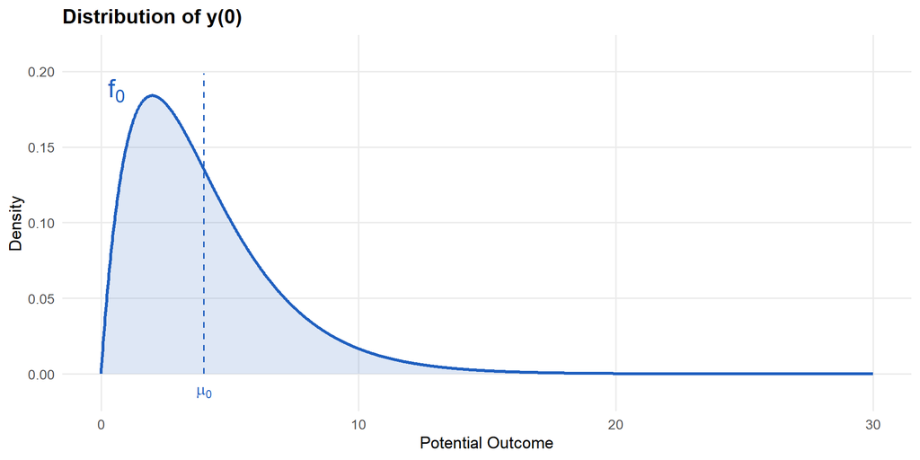

If TEs are homogeneous, then $y_i\small{(1)} = y_i\small{(0)} + \tau$ (i.e. a mean shift)

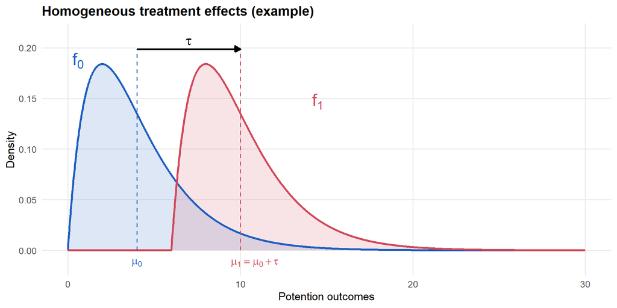

The variance does not change.

## Homogenous TEs

If TEs are **homogenous**

$$Var(\hat{\tau}) = \frac{\sigma_0^2}{n_0} + \frac{\sigma_1^2}{n_1} = \sigma^2\bigg(\frac{1}{n_1} + \frac{1}{n_0}\bigg)$$

Which can be estimated as,

$$\hat{\sigma}^2 = \frac{1}{n-2}\big((n_0-1)\times \hat\sigma_0^2 + (n_1-1)\times \hat\sigma_1^2 \big)$$

We call this the **constant variance estimator**.

If the TEs are heterogeneous, then $y_i\small{(1)} = y_i\small{(0)} + \tau_i$

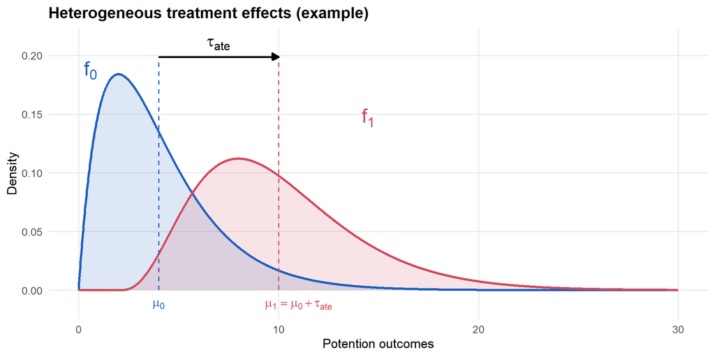

## Distribution

Note, we do not know the distribution of $y_i\small{(0)}$ or $y_i\small{(1)}$!

- In applied work, researchers prefer not to make any assumptions
- Rely on CLT to show asymptotic distribution is normal
- In practice, and since RCTs often have a small sample, use $t$-distribution to be more conservative
- There are other approaches to inference (e.g., permutation tests like Fisher’s exact $p$-value) that we won’t cover here, but are more relevant for small samples.

## In Stata/R

- Stata
- R

Constant variance test

```stata
ttest belief_err_bl, by(treat)
```

```
Two-sample t test with equal variances
------------------------------------------------------------------------------
   Group |     Obs        Mean    Std. err.   Std. dev.   [95% conf. interval]
---------+--------------------------------------------------------------------
       0 |     674    20.61721    .5519379    14.32914    19.53348    21.70094
       1 |     638    20.23511    .5867858    14.82142    19.08284    21.38738
---------+--------------------------------------------------------------------
Combined |   1,312     20.4314    .4021444    14.56629    19.64249    21.22032
---------+--------------------------------------------------------------------
    diff |             .382101    .8048296               -1.196795    1.960997
------------------------------------------------------------------------------
    diff = mean(0) - mean(1)                                      t =   0.4748
H0: diff = 0                                     Degrees of freedom =     1310

    Ha: diff < 0                 Ha: diff != 0                 Ha: diff > 0
 Pr(T < t) = 0.6825         Pr(|T| > |t|) = 0.6350          Pr(T > t) = 0.3175
```

Unequal variance test (Neyman)

```stata
ttest belief_err_bl, by(treat) unequal
```

```
Two-sample t test with unequal variances
------------------------------------------------------------------------------
   Group |     Obs        Mean    Std. err.   Std. dev.   [95% conf. interval]
---------+--------------------------------------------------------------------
       0 |     674    20.61721    .5519379    14.32914    19.53348    21.70094
       1 |     638    20.23511    .5867858    14.82142    19.08284    21.38738
---------+--------------------------------------------------------------------
Combined |   1,312     20.4314    .4021444    14.56629    19.64249    21.22032
---------+--------------------------------------------------------------------
    diff |             .382101    .8055762               -1.198271    1.962473
------------------------------------------------------------------------------
    diff = mean(0) - mean(1)                                      t =   0.4743
H0: diff = 0                     Satterthwaite's degrees of freedom =  1299.78

    Ha: diff < 0                 Ha: diff != 0                 Ha: diff > 0
 Pr(T < t) = 0.6823         Pr(|T| > |t|) = 0.6354          Pr(T > t) = 0.3177
```

Constant variance test

```r
t.test(belief_err_bl ~ treat, data = dr19_dta, var.equal = TRUE)
```

```
    Two Sample t-test

data:  belief_err_bl by treat
t = 0.47476, df = 1310, p-value = 0.635
alternative hypothesis: true difference in means between group 0 and group 1 is not equal to 0
95 percent confidence interval:
 -1.196795  1.960997
sample estimates:
mean in group 0 mean in group 1
       20.61721        20.23511
```

Unequal variance test (Neyman)

```r
t.test(belief_err_bl ~ treat, data = dr19_dta, var.equal = FALSE)
```

```
    Welch Two Sample t-test

data:  belief_err_bl by treat
t = 0.47432, df = 1299.8, p-value = 0.6354
alternative hypothesis: true difference in means between group 0 and group 1 is not equal to 0
95 percent confidence interval:
 -1.198271  1.962473
sample estimates:
mean in group 0 mean in group 1
       20.61721        20.23511
```

# Linear Model

## Dummy regressor

We know that for a discrete $x_i\in\{0,1\}$,

$$y_i = \beta_0 + \beta_1 x_i + u_i$$

where,
$$\beta_1 = E[y_i|x_i=1]-E[y_i|x_i=0]$$

## OLS

Moreover, we showed in Lecture 2 that the OLS estimator for $\beta_1$ is just,

$$\hat{\beta}_1 = \bar{y}_1 - \bar{y}_0$$

## Translation of POF

We can translate the POF to a linear regression model,<sup>1</sup>

$$\begin{aligned}
y_i =& y_i\small{(0)} + w_i(y_i\small{(1)}-y_i\small{(0)}) \\
=& y_i\small{(0)} + \tau_i w_i \\
=& \textcolor{blue}{E[y_i\small{(0)}]} + \tau_i w_i + y_i\small{(0)}-\textcolor{blue}{E[y_i\small{(0)}]} \\
=& \textcolor{blue}{E[y_i\small{(0)}]} + \textcolor{red}{\tau_{ate}} w_i + \underbrace{y_i\small{(0)}-\textcolor{blue}{E[y_i\small{(0)}]} + (\tau_i-\textcolor{red}{\tau_{ate}})w_i}_{u_i} \\
=& \alpha_0 + \textcolor{red}{\tau_{ate}}w_i + u_i
\end{aligned}$$

[^7]: Wooldridge (2025, sec. 2.7a) also includes a version with homogeneous TEs. This is the more general case.

Consider the error term:

$$u_i = \underbrace{y_i\small{(0)}-\textcolor{blue}{E[y_i\small{(0)}]}}_{1.} + \underbrace{(\tau_i-\textcolor{red}{\tau_{ate}})}_{2.}\underbrace{w_i}_{3.}$$

it includes,

1. the deviation of $y_i(0)$ from its unconditional mean
2. the devation of $\tau_i$ from its unconditional mean (i.e. $\tau_{ate}$) $\Leftarrow$ **heterogeneity**
3. $w_i$ is found in the error term, as well

Solve for $E[u_i|w_i=0]$

$$\begin{aligned}
E[u_i|w_i=0] =& E\big[y_i\small{(0)}-\textcolor{blue}{E[y_i\small{(0)}]} + (\tau_i-\textcolor{red}{\tau_{ate}})w_i\big|w_i=0\big] \\
=&E\big[y_i\small{(0)}-\textcolor{blue}{E[y_i\small{(0)}]}\big|w_i=0\big] \\
=& E[y_i\small{(0)}|w_i=0]-\textcolor{blue}{E[y_i\small{(0)}]} \\
\end{aligned}$$

*If assignment is unconfounded*:

$$E[y_i\small{(0)}|w_i=0]-\textcolor{blue}{E[y_i\small{(0)}]} = E[y_i\small{(0)}]-\textcolor{blue}{E[y_i\small{(0)}]} = 0$$

Solve for $E[u_i|w_i=1]$

$$\begin{aligned}
E[u_i|w_i=1] =& E\big[y_i\small{(0)}-\textcolor{blue}{E[y_i\small{(0)}]} + (\tau_i-\textcolor{red}{\tau_{ate}})w_i\big|w_i=1\big] \\
=& E\big[y_i\small{(0)}-\textcolor{blue}{E[y_i\small{(0)}]} + y_i\small{(1)}-y_i\small{(0)}-\textcolor{red}{E[y_i\small{(1)}]}+\textcolor{red}{E[y_i\small{(0)}]}\big|w_i=1\big] \\
=& E\big[y_i\small{(1)}-\textcolor{red}{E[y_i\small{(1)}]}\big|w_i=1\big] \\
=& E[y_i\small{(1)}|w_i=1] -\textcolor{red}{E[y_i\small{(1)}]}
\end{aligned}$$

Again, *if assignment is unconfounded*:

$$E[y_i\small{(1)}|w_i=1] -\textcolor{red}{E[y_i\small{(1)}]} = E[y_i\small{(1)}]-\textcolor{red}{E[y_i\small{(1)}]} = 0$$

Thus, with unconfounded assignment we can write,

$$y_i = \alpha_0 + \tau_{ate}w_i + u_i$$

where,

- slope parameter on $w_i$ identifies the ATE
- the error term fulfills MLR 4
- OLS estimator is unbiased (for the ATE)

## Error variance

We have shown that under unconfoundedness $E[u_i |w_i]=0$.<sup>1</sup> What about:

$$Var(u_i|w_i)=E[u_i^2|w_i]=?$$

- Suppose TEs are **homogenous**: $\tau_i = \tau = \tau_{ate}\;\forall\;i$

  $$u_i = y_i\small{(0)}-\textcolor{blue}{E[y_i\small{(0)}]} + \underbrace{(\tau_i-\textcolor{red}{\tau_{ate}})}_{=0}w_i = y_i\small{(0)}-\textcolor{blue}{E[y_i\small{(0)}]}$$
[^8]: Where $u_i = y_i - \alpha_0 - \tau_{ate}w_i$.

## Homoskedasticity

If treatment effects are **homogeneous**, then

$$E[u_i^2|w_i] = E[(y_i\small{(0)}-\textcolor{blue}{E[y_i\small{(0)}]})^2|w_i] = E[(y_i\small{(0)}-\textcolor{blue}{E[y_i\small{(0)}]})^2] = \sigma^2_0 = \sigma^2$$

*under unconfoundedness*.

- homogeneity $\Rightarrow$ homoskedastic error variance

## Heteroskedasticity

If TEs are **heterogenous**:

$$E[u_i^2|w_i] = \begin{cases}
E[(y_i\small{(0)}-\textcolor{blue}{E[y_i\small{(0)}]})^2] = \sigma^2_0 \quad \text{if}\;w_i=0 \\
E[(y_i\small{(1)}-\textcolor{red}{E[y_i\small{(1)}]})^2] = \sigma^2_1 \quad \text{if}\;w_i=1 \\
\end{cases}$$

*under unconfoundedness*.

- heterogeneity $\Rightarrow$ heteroskedastic error variance

## Variance estimator

We know from Lecture 3 that the (conditional) variance of the OLS estimator for $\tau_{ate}$ is,

$$\widehat{Var}(\hat{\tau}_{ols}|W) = \frac{\hat{\sigma}^2_{ols}}{SST_w}$$

**under MLR 5** ($\Leftarrow$ homogeneous TEs). Where,

$$\hat{\sigma}^2_{ols} = \frac{1}{n-2}\sum_{i=1}^n \hat{u}_i^2$$

This is mathematically equivalent to the constant variance estimator.

$$= \frac{1}{n-2}\big((n_0-1)\times\hat\sigma_0^2 + (n_1-1)\times\hat\sigma_1^2\big)$$

In the denominator is

$$SST_w = n\bar{w}(1-\bar{w})$$

This formula is quadratic in $\bar{w}$ - the share of the sample treated.

- At $\bar{w}=0.5$, $SST_w$ is maximized and $Var(\hat{\tau}^{OLS}|W)$ is minimized (holding other factors fixed).
- A balanced treatment is good for statistical power, as is a larger sample size.

What if MLR 5 ($\Leftarrow$ heterogeneous TEs) does not hold?

- The White (1980) heteroskedastic-consistent estimator from Lecture 5 was,

$$HC0 = \frac{\sum_{i=1}^{n}(w_{i}-\bar{w})^2\hat{u}_i^2}{\text{SST}_w^2}$$

It can be shown (we will not) that,

$$HC0 \neq \frac{\hat{\sigma}_0^2}{n_0} + \frac{\hat{\sigma}_1^2}{n_1} = HC2$$

The Neyman estimator is numerically equivalent to HC2.

- in practice, all HC0-HC3 estimators are asymptotically consistent.
- HC3 is recommended for smaller samples.

# Regression Adjustment

## Purpose

The variance of the estimator is (assuming homogeneous TEs),

$$Var(\hat{\tau}_{ols}|W) = \frac{Var(u_i|w_i)}{SST_w} = \frac{\sigma^2_u}{SST_w}$$

where $u_i$ is from the model,

$$y_i = \alpha_0 + \tau_{ate}w_i + u_i$$

- The only variation in $y$ explained by this model is the difference between treatment-control.
- Will result in high variance and low-powered test.

## Covariates

Suppose,

$$u_i = \gamma x_i + v_i$$

where $x$ is a regressor measured before assignment<sup>1</sup>

- likely explain part of the outcome (i.e. $\gamma\neq 0$)
- commonly referred to as baseline covariates in RCTs
[^9]: We can extend the notation to include multiple regressors, but it makes some of the math a little difficult. The conclusion does not change.

## Regression adjustment

Instead of the simple regression, we estimate

$$y_i = \alpha_0 + \tau_{ate}w_i + \gamma x_i + v_i$$

- Wooldridge (2025, 257) refers to this as the Restricted Regression Adjustment (RRA)

## Variance

From Lecture 3 we know,

$$Var(\hat{\tau}_{rra}|W,X) = \frac{Var(v_i|w_i,x_i)}{SSR_w} = \frac{\sigma^2_v}{SSR_w}$$

where,

$$SSR_w=SST_w (1-R_w^2)$$

- $R^2_w$ is the amount of variance in assignment explained by the covariates. **This should be low, but won’t be zero.**
- While $R^2_w\neq 0$ in the finite sample, $R^2_w\rightarrow 0$ as $n\rightarrow \infty$
- So, $SSR_w\approx SST_w$.

## Error variance

The improvement in power comes from the fact that,

$$\underbrace{Var(u_i|w_i)}_{\sigma^2_u} = Var(\gamma x_i + v_i|w_i) = \underbrace{\gamma^2 Var(x_i)}_{>0} + \underbrace{Var(v_i|w_i,x_i)}_{\sigma^2_v}$$

assuming

- $Cov(x_i,v_i|w_i)=0$
- $w_i$ is assigned independently of $x_i$: $Var(x_i|w_i) = Var(x_i)$
- $Var(v_i|w_i)=Var(v_i|w_i,x_i)$ ($\Leftarrow$ heterogeneity unrelated to $x$)

## Power

Putting these two together,

$$Avar(\hat{\tau}_{rra}) \leq Avar(\hat{\tau}_{ols})$$

where $Avar()$ is the asymptotic variance.<sup>1</sup>

Adding covariates,

- Reduces variance of the estimator by reducing the error variance
- Little trade-off in terms of the correlation between $w$ and $x$ (i.e., $R^2_w$) under assignment that is unconfounded (w.r.t. $x$’s).
  - Any finite sample correlation disappears as $n\rightarrow \infty$.
  - **Covariates must not be potential outcomes of the experiment** (i.e. baseline).
[^10]: This is a place holder for $p\lim \hat\sigma^2/(n^{-1}SSR_w)$.

# Example: Reivisiting Dizon-Ross (2019)

## RCT

Why randomize?

- Resolves the problem of self-selection
- Information parents have is endogenous
- Randomizing who gets information resolves this (in expectation)

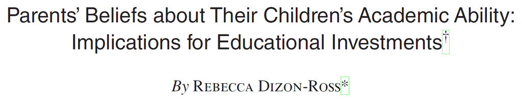

## Research Design

Baseline survey:

- Measure covariates: balance and power

Endline survey:

- Measure outcomes
- Need to think about attrition

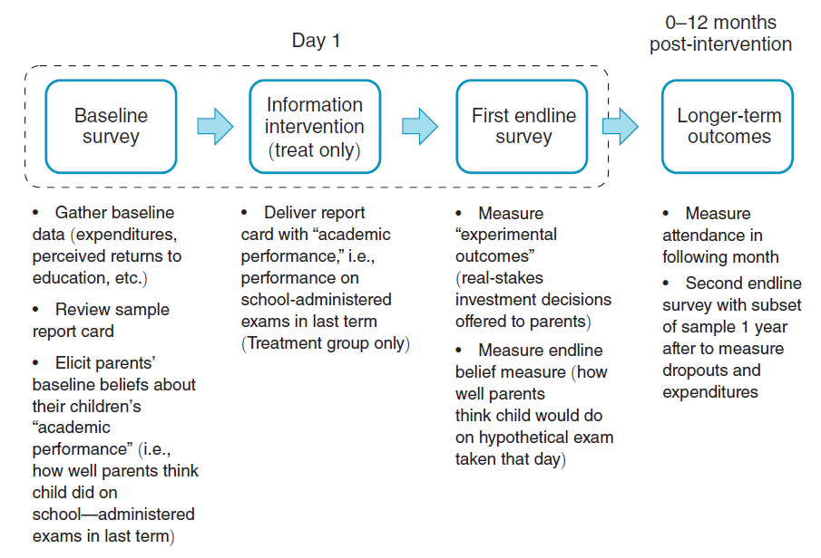

## Balance

Balance:

- Test on observables
- Doesn’t consider unobservables
- Will be non-zero correlation in data
- Validates research design

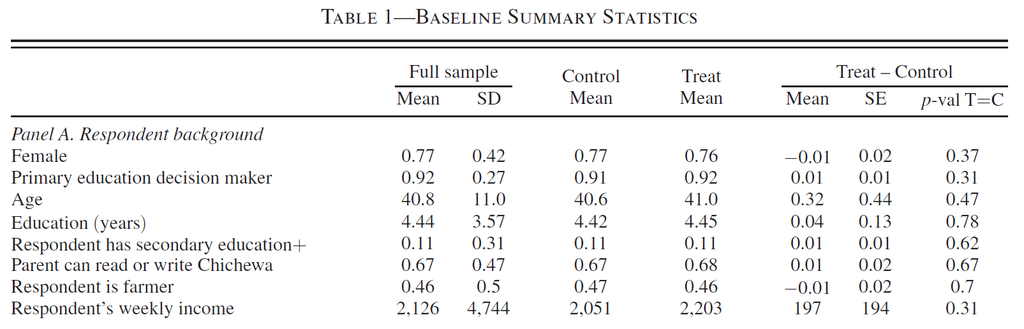

## Simple difference between means

SDM:

- Measures ATE under unconfoundedness
- Might have a high variance

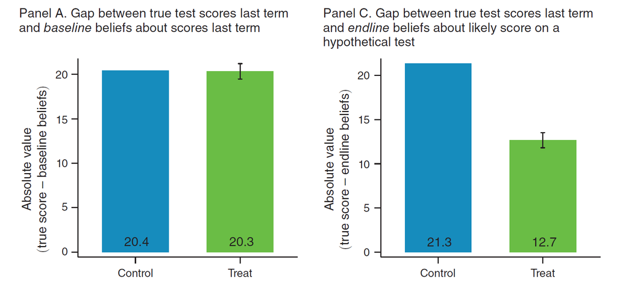

## Heterogeneity

Heterogeneity:

- POF developed to understand heterogeneous TEs
- Researchers will often commit to important margins of heterogeneity in their pre-analysis.

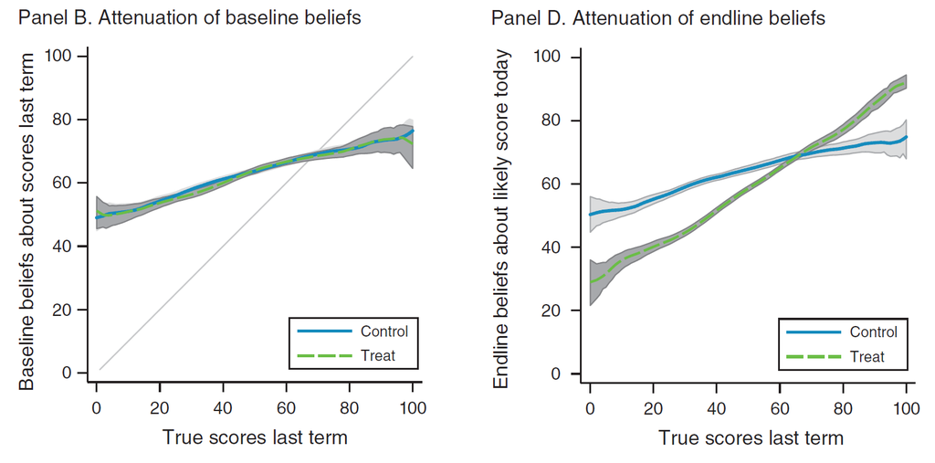

## Regression

Regression adjustment:

- Can correct for any imbalance
- More valuable as a source of improved power
- Covariates from baseline (i.e. not outcomes of experiment)

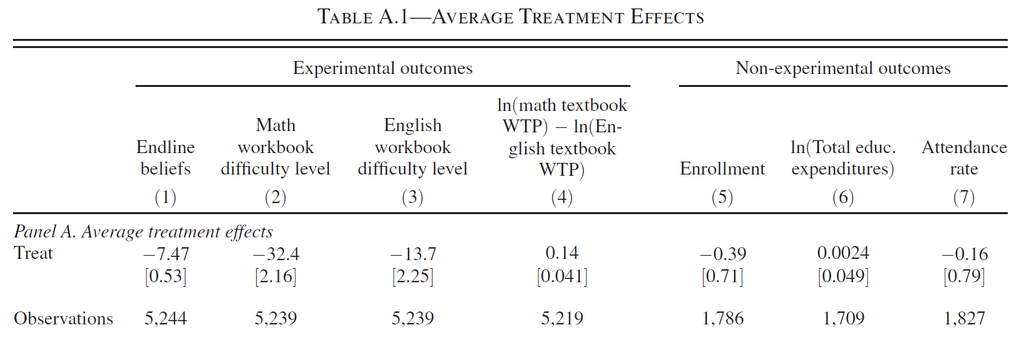

# References

## Bibliography

Bertrand, Marianne, and Sendhil Mullainathan. 2004. “Are Emily and Greg More Employable Than Lakisha and Jamal? A Field Experiment on Labor Market Discrimination.” *American Economic Review* 94 (4): 991–1013.

Dizon-Ross, Rebecca. 2019. “Parents’ Beliefs about Their Children’s Academic Ability: Implications for Educational Investments.” *American Economic Review* 109 (8): 2728–65.

Heckman, James J, and Rodrigo Pinto. 2022. “Causality and Econometrics.” National Bureau of Economic Research.

Holland, Paul W. 1986. “Statistics and Causal Inference.” *Journal of the American Statistical Association* 81 (396): 945–60.

Imbens, Guido W, and Donald B Rubin. 2015. “Causal Inference in Statistics, Social, and Biomedical Sciences.” *New York* 517.

Imbens, Guido W, and Jeffrey M Wooldridge. 2009. “Recent Developments in the Econometrics of Program Evaluation.” *Journal of Economic Literature* 47 (1): 5–86.

Oreopoulos, Philip. 2011. “Why Do Skilled Immigrants Struggle in the Labor Market? A Field Experiment with Thirteen Thousand Resumes.” *American Economic Journal: Economic Policy* 3 (4): 148–71.

Rubin, Donald B. 1975. “Bayesian Inference for Causality: The Importance of Randomization.” In *Proceedings of the Social Statistics Section of the American Statistical Association*, 233–39. American Statistical Association, Alexandria, VA.

Wooldridge, Jeffrey M. 2025. “Introductory Econometrics: A Modern Approach.”